# Quant Project

2025-11-18

## Introduction & Motivation

The asset selection follows a geopolitical theme: how defense contractors and energy majors react to rising geopolitical tension. The question emerged after Germany announced its rearmament plans in 2024 and a friend’s Rheinmetall shares climbed steadily over the following months. His intuition was simple—that higher geopolitical risk translates into higher defense returns—but the gradual nature of that rise made me wonder how systematic the effect really is. Do defense primes reliably appreciate as tensions build? And do energy majors show similar behavior because oil markets respond to conflict, sanctions, and supply disruptions through a different channel? Defense firms react to procurement cycles and budget announcements, while energy firms react to commodity shocks, yet both sectors are repeatedly pulled by the same geopolitical events.

The working hypotheses are:

- **H1:** Defense stocks exhibit right-skewed returns, with upward moves clustering around increases in military budgets or major procurement announcements.
- **H2:** Energy stocks display heavier tails, reflecting oil-price shocks and supply-chain disruptions during tense geopolitical periods.
- **H3:** Correlations between both sectors rise when geopolitical risk increases, even though the underlying transmission mechanisms differ.

## 2 Data collection and Preprocessing

### 2.1 Load Libraries and download prices

```
##  [1] "LMT"  "NOC"  "RTX"  "GD"   "HII"  "XOM"  "CVX"  "SHEL" "COP"  "EOG"
```

### 2.2 Structure and completeness

```
##      Index                 LMT             NOC             RTX
##  Min.   :2018-01-02   Min.   :204.7   Min.   :202.5   Min.   : 41.24
##  1st Qu.:2019-12-19   1st Qu.:307.4   1st Qu.:293.6   1st Qu.: 69.13
##  Median :2021-12-07   Median :350.3   Median :356.3   Median : 80.04
##  Mean   :2021-12-09   Mean   :369.9   Mean   :380.6   Mean   : 86.04
##  3rd Qu.:2023-11-27   3rd Qu.:435.0   3rd Qu.:455.6   3rd Qu.: 93.18
##  Max.   :2025-11-18   Max.   :597.8   Max.   :638.0   Max.   :179.44
##        GD              HII             XOM              CVX
##  Min.   : 93.13   Min.   :122.8   Min.   : 24.15   Min.   : 41.97
##  1st Qu.:157.18   1st Qu.:181.7   1st Qu.: 52.03   1st Qu.: 86.05
##  Median :189.54   Median :196.2   Median : 60.67   Median : 98.63
##  Mean   :201.52   Mean   :202.6   Mean   : 73.41   Mean   :112.51
##  3rd Qu.:238.05   3rd Qu.:221.1   3rd Qu.:101.66   3rd Qu.:143.39
##  Max.   :353.77   Max.   :324.2   Max.   :119.95   Max.   :165.55
##       SHEL            COP              EOG
##  Min.   :17.40   Min.   : 18.33   Min.   : 22.76
##  1st Qu.:41.86   1st Qu.: 47.47   1st Qu.: 63.79
##  Median :48.11   Median : 63.73   Median : 91.84
##  Mean   :48.79   Mean   : 71.96   Mean   : 87.16
##  3rd Qu.:59.08   3rd Qu.: 98.73   3rd Qu.:114.12
##  Max.   :76.28   Max.   :126.44   Max.   :133.44
```

```
##  LMT  NOC  RTX   GD  HII  XOM  CVX SHEL  COP  EOG
##    0    0    0    0    0    0    0    0    0    0
```

Interpretation: The merged price matrix spans Jan 2018 to today with uninterrupted histories for all ten tickers. The quartiles and ranges differ widely across sectors—defense names trend higher and smoother, while energy names show large swings tied to commodity cycles. Importantly, no missing values appear before cleaning, confirming stable coverage from Yahoo Finance across the full period.

### 2.3 Missing values

```
##  LMT  NOC  RTX   GD  HII  XOM  CVX SHEL  COP  EOG
##    0    0    0    0    0    0    0    0    0    0
```

Interpretation: Because the panel is already complete, no adjustments are required. Forward-filling is kept in the code only as a safeguard, since occasional calendar mismatches may appear when rendering on another machine or if Yahoo Finance later updates its data. In practice, the current dataset needs no correction.

### 2.4 Compute simple and log returns

```
##                     LMT           NOC         RTX           GD          HII
## 2018-01-03  0.008346497  0.0046084583 0.014562467  0.006215542  0.006034201
## 2018-01-04  0.017008665  0.0061768936 0.003148032  0.017053950  0.014154653
## 2018-01-05  0.009019168 -0.0010700349 0.008549048 -0.002488392  0.004674118
## 2018-01-08 -0.004621281  0.0001304328 0.009455798  0.000000000  0.009748910
## 2018-01-09  0.007135566  0.0068855834 0.010858064  0.005748209  0.013298958
## 2018-01-10  0.001632283 -0.0089971803 0.004680925 -0.005503854 -0.007848781
##                      XOM          CVX          SHEL          COP           EOG
## 2018-01-03  0.0194501307  0.007262784  0.0080509118  0.018270706  0.0148026335
## 2018-01-04  0.0013827091 -0.003117376  0.0043645550  0.011470828  0.0001803327
## 2018-01-05 -0.0008063797 -0.001640313  0.0021748396 -0.001932155  0.0109360677
## 2018-01-08  0.0044857360  0.004913726  0.0002897056  0.010145033  0.0048024045
## 2018-01-09 -0.0042550310 -0.005383122 -0.0042080187  0.008146743 -0.0089120072
## 2018-01-10 -0.0079842051  0.006393715  0.0039183131 -0.004845293  0.0026821062
```

```
##      Index                 LMT                  NOC
##  Min.   :2018-01-03   Min.   :-0.1365259   Min.   :-0.1353264
##  1st Qu.:2019-12-20   1st Qu.:-0.0059595   1st Qu.:-0.0072459
##  Median :2021-12-08   Median : 0.0006504   Median : 0.0009177
##  Mean   :2021-12-10   Mean   : 0.0003054   Mean   : 0.0003762
##  3rd Qu.:2023-11-28   3rd Qu.: 0.0075383   3rd Qu.: 0.0084739
##  Max.   :2025-11-18   Max.   : 0.1019057   Max.   : 0.1222279
##       RTX                   GD                  HII
##  Min.   :-0.1563794   Min.   :-0.1157056   Min.   :-0.3032794
##  1st Qu.:-0.0071429   1st Qu.:-0.0069419   1st Qu.:-0.0079061
##  Median : 0.0005928   Median : 0.0008679   Median : 0.0008814
##  Mean   : 0.0004829   Mean   : 0.0003602   Mean   : 0.0002348
##  3rd Qu.: 0.0082856   3rd Qu.: 0.0080246   3rd Qu.: 0.0100682
##  Max.   : 0.1463245   Max.   : 0.0875304   Max.   : 0.1165053
##       XOM                  CVX                  SHEL
##  Min.   :-0.1303911   Min.   :-0.2500620   Min.   :-0.1884063
##  1st Qu.:-0.0095564   1st Qu.:-0.0080567   1st Qu.:-0.0084362
##  Median : 0.0004915   Median : 0.0009616   Median : 0.0006973
##  Mean   : 0.0003545   Mean   : 0.0002681   Mean   : 0.0002303
##  3rd Qu.: 0.0105914   3rd Qu.: 0.0092541   3rd Qu.: 0.0093866
##  Max.   : 0.1194416   Max.   : 0.2049034   Max.   : 0.1796469
##       COP                  EOG
##  Min.   :-0.2855517   Min.   :-0.3857686
##  1st Qu.:-0.0113632   1st Qu.:-0.0118640
##  Median : 0.0002283   Median : 0.0002447
##  Mean   : 0.0003748   Mean   : 0.0001474
##  3rd Qu.: 0.0130090   3rd Qu.: 0.0122829
##  Max.   : 0.2248530   Max.   : 0.1533238
```

### 2.5 Save cleaned dataset

```
## Cleaned datasets successfully saved as 'prices_clean.csv' and 'log_returns.csv'.
```

## 3 Risk & Return Diagnostics

This section examines the distributional properties and dependence structure of the ten assets. I compute annualized means and volatilities, skewness, excess kurtosis, and key percentiles; visualize the empirical distributions; and run formal normality tests (Shapiro–Wilk, Jarque–Bera, Kolmogorov–Smirnov). Finally, I compare Pearson, Spearman, and Kendall correlations to evaluate linear and rank-based dependence across the defense and energy sectors.

### 3.1 Descriptive Statistics

Daily log returns are transformed into annualized moments using the standard 252-day convention. Excess kurtosis and pronounced skewness—as expected for financial returns—indicate clear deviations from normality. Percentile-based tail measures confirm the presence of occasional large moves, especially for energy majors exposed to oil-price shocks.

```
##      Mean_Ann SD_Ann Skewness Kurtosis      1%      5%   50%    95%    99%
## LMT    0.0770 0.2506  -0.9326  10.7936 -0.0464 -0.0221 7e-04 0.0213 0.0423
## NOC    0.0948 0.2693  -0.2848   5.6967 -0.0517 -0.0252 9e-04 0.0238 0.0427
## RTX    0.1217 0.2991  -0.4314   9.8087 -0.0521 -0.0254 6e-04 0.0261 0.0490
## GD     0.0908 0.2394  -0.4518   3.8574 -0.0422 -0.0234 9e-04 0.0228 0.0397
## HII    0.0592 0.3201  -2.5195  31.9781 -0.0517 -0.0274 9e-04 0.0263 0.0547
## XOM    0.0893 0.3032  -0.2192   2.5329 -0.0509 -0.0288 5e-04 0.0293 0.0488
## CVX    0.0676 0.3170  -1.0837  22.8986 -0.0489 -0.0274 1e-03 0.0272 0.0478
## SHEL   0.0580 0.3232  -0.9685  14.0196 -0.0573 -0.0283 7e-04 0.0284 0.0512
## COP    0.0944 0.3988  -0.6498  13.1519 -0.0682 -0.0356 2e-04 0.0355 0.0584
## EOG    0.0371 0.4257  -1.4439  21.7423 -0.0682 -0.0389 2e-04 0.0408 0.0698
```

Interpretation: All ten assets exhibit positive annualized mean returns, but these are small relative to their volatilities: risk clearly dominates reward at the daily horizon. Skewness is mostly negative, meaning large down moves are more common than large up moves, with especially pronounced left tails for some defense contractors and high-beta energy names. Excess kurtosis is large across the board, signalling heavy tails and occasional extreme shocks rather than thin-tailed Gaussian noise.

### 3.2 Distributional Visualizations

To illustrate distributional asymmetries and deviations from normality, I plot histograms with kernel densities, empirical CDFs, and QQ-plots for two representative assets: one defense stock (LMT) and one energy major (XOM). These highlight the different “war-sensitivity” channels: policy-driven jumps for defense and commodity-driven left/right tail risk for energy.

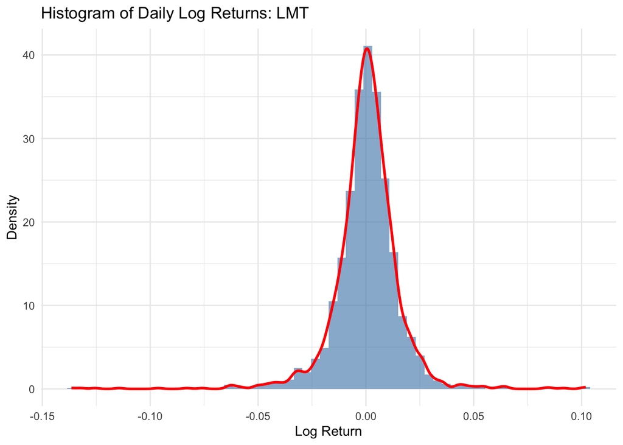

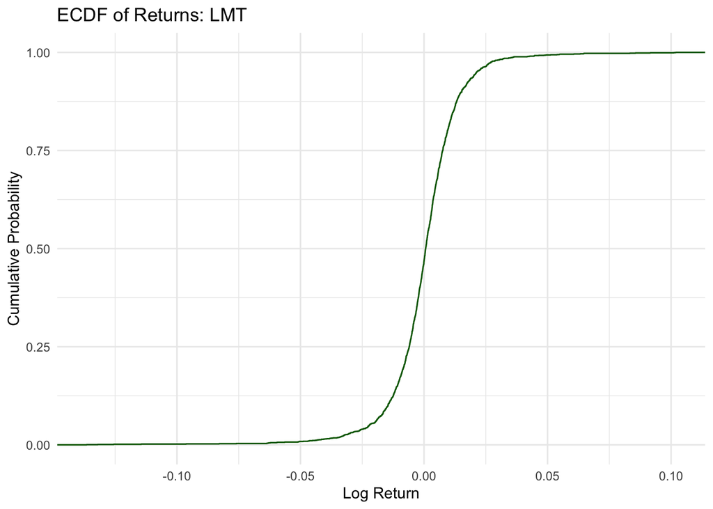

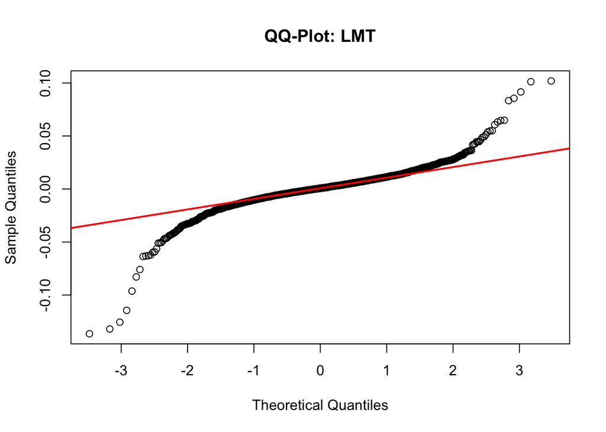

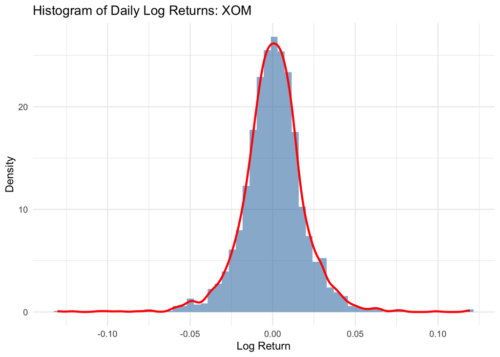

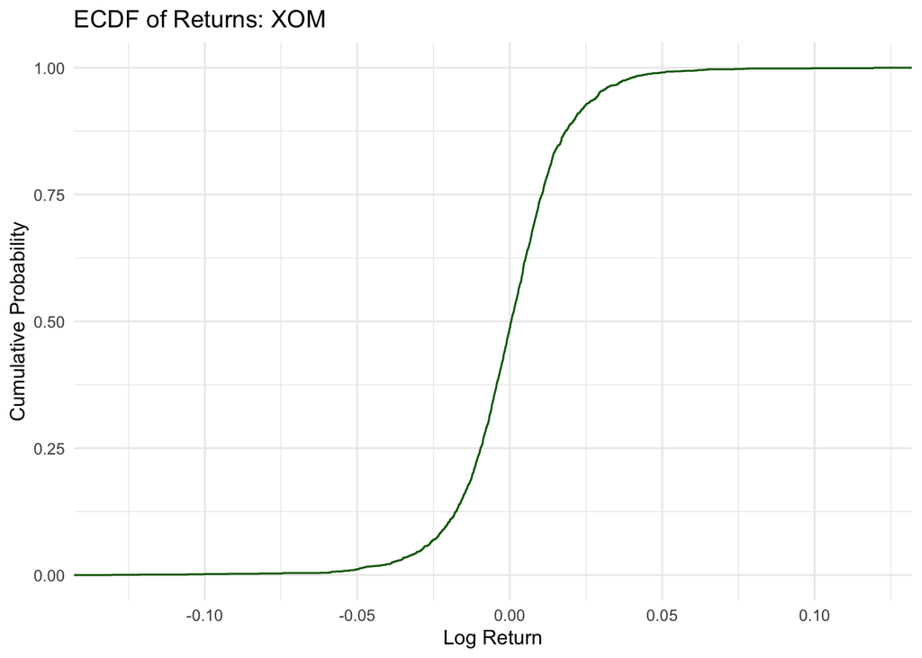

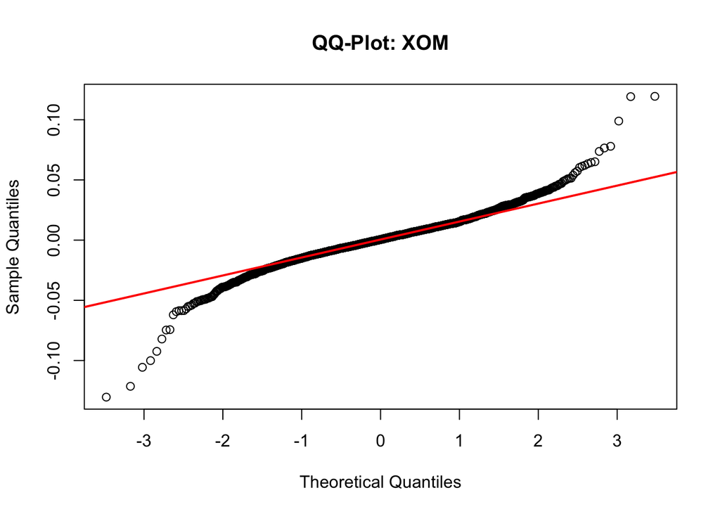

### 3.3 Normality Tests

I formally test normality using Shapiro–Wilk, Jarque–Bera, and Kolmogorov–Smirnov tests. All three tests consistently reject normality across the ten assets, reflecting well-known stylized facts of financial returns: nonlinear dependence, fat tails, and conditional heteroskedasticity.

```
##      Shapiro_stat Shapiro_p    JB_stat JB_p KS_stat KS_p
## LMT        0.8609         0  15991.822    0  0.0983    0
## NOC        0.9040         0   6269.632    0  0.0835    0
## RTX        0.8569         0  13603.488    0  0.1068    0
## GD         0.9234         0   3948.788    0  0.0736    0
## HII        0.8330         0 103082.678    0  0.1038    0
## XOM        0.9454         0   2542.743    0  0.0616    0
## CVX        0.8445         0  55751.472    0  0.0967    0
## SHEL       0.8549         0  24219.382    0  0.0975    0
## COP        0.8898         0  21673.162    0  0.0727    0
## EOG        0.8915         0  51218.664    0  0.0790    0
```

Interpretation: All three tests produce essentially zero p-values for every asset, so normality is decisively rejected. Combined with the skewness and kurtosis results, this supports modelling choices that allow for heavy tails and time-varying volatility later in the report, rather than relying on simple Gaussian assumptions.

### 3.4 Dependence Structure: Pearson, Spearman, Kendall

I compute three correlation matrices: - Pearson: linear dependence - Spearman: rank-based monotonic dependence - Kendall: concordance-based dependence robust to outliers

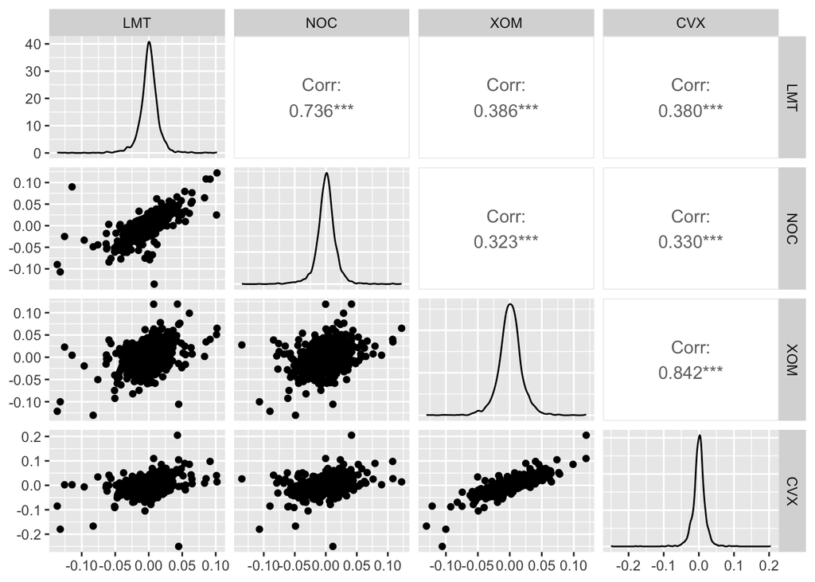

```
##   Pearson Spearman Kendall
## 1    0.54    0.508   0.371
```

Interpretation: Average correlations are clearly positive and moderate across the universe: all three measures cluster around a similar level, which means the assets tend to move together when broad market or macro shocks hit. At the same time, correlations are far from one, so diversification both within and across sectors still reduces idiosyncratic noise. The similarity between Pearson and rank-based measures suggests mainly monotonic co-movements with some nonlinearities but no extreme rank reversals.

## 4 Capital Allocation & Mean–Variance Portfolio

This section applies Markowitz portfolio theory to the ten risky assets. Using annualized means and covariances from daily log returns, I compute the Global Minimum Variance (GMV) portfolio, generate the no-short-selling Efficient Frontier, and recover the Tangency Portfolio as the solution that maximizes the Sharpe ratio given a 4% risk-free rate. I also illustrate the Capital Allocation Line (CAL) and interpret how risk aversion affects the optimal allocation to the tangency portfolio.

### 4.1 Mean–Variance Inputs

Expected returns and covariances are annualized using standard 252-day scaling. The mean–variance setup is fully determined by the vector of expected returns μ and the covariance matrix Σ.

Interpretation: Annualizing daily log returns translates the high-frequency behavior of each asset into long-run moments suitable for portfolio optimization. The covariance matrix shows that both sectors share meaningful common risk, but energy names introduce noticeably higher variance due to their exposure to oil-price shocks. Defense stocks contribute more stable, policy-driven patterns. These inputs fully determine the shape of the efficient frontier under the no-short-selling constraint.

### 4.2 Global Minimum Variance (GMV) Portfolio

The GMV portfolio is obtained by minimizing w′Σw subject to full investment and no short-selling. Quadratic programming returns the unique solution with the lowest possible variance among all feasible portfolios.

### 4.3 Efficient Frontier

To trace the Efficient Frontier, I solve a quadratic program for each target return in a grid between the minimum and maximum expected return. The resulting set of feasible portfolios defines the standard Markowitz frontier.

### 4.4 Tangency Portfolio (Maximum Sharpe)

Using a 4% annual risk-free rate, the tangency portfolio maximizes the Sharpe ratio and defines the slope of the Capital Allocation Line.

### 4.5 Efficient Frontier Plot with GMV, Tangency, and CAL

[figure not shown]

Interpretation: The plot highlights the three key elements of classical capital allocation: • the GMV portfolio anchors the leftmost point of the frontier, • the tangency portfolio sits higher on the curve at the point of maximum slope, and • the Capital Allocation Line extends from the risk-free rate through the tangency portfolio. The slope of the CAL is modest, consistent with a risky universe where expected returns are small relative to volatility. Investors choosing any combination along the CAL hold the same risky portfolio (the tangency portfolio) but scale it up or down depending on their desired risk level.

### 4.6 Capital Allocation for a Given Risk Aversion

Using the CAPM formula, investors choose a point on the CAL based on their risk aversion parameter A. For example, with A = 3, the optimal weight in the tangency portfolio is:

```
## [1] 0.3666976
```

Interpretation: The optimal share of wealth placed in the tangency portfolio decreases as risk aversion rises. With a moderately risk-averse investor (A = 3), the weight in the tangency portfolio is well below 1, meaning the investor holds a mix of the risk-free asset and the tangency portfolio rather than leveraging into risky assets. This behavior is consistent with the frontier results: the Sharpe ratio is positive but not strong enough to justify aggressive risk-taking for investors who dislike volatility.

## 5 Asset Pricing: CAPM and Macro–Factor Models

This section tests whether a simple CAPM with the S&P 500 as market proxy can explain the cross-section of defense and energy returns, and then extends it to a macro-factor specification. The focus is on betas, Jensen’s alphas, and the split between systematic and idiosyncratic risk. Finally, I use factor-adjusted expected returns to construct a simple optimal long-only portfolio.

### 5.1 CAPM estimation vs S&P 500

```r
# Market proxy: S&P 500
getSymbols("^GSPC", from = from, to = to, src = "yahoo", auto.assign = TRUE)
```

```
## [1] "GSPC"
```

```r
MKT    <- Ad(GSPC)
MKT_ret <- na.omit(ROC(MKT, type = "continuous"))

# Align market and asset returns (daily log returns)
aligned <- na.omit(merge(log_returns, MKT_ret))
colnames(aligned)[ncol(aligned)] <- "MKT"

assets <- colnames(log_returns)

#CAPM regressions: r_i,t = alpha_i + beta_i * r_MKT,t + e_t
capm_list <- lapply(assets, function(sym){
model <- lm(aligned[, sym] ~ aligned$MKT)
sm    <- summary(model)
coefs <- coef(sm)
data.frame(
Asset     = sym,
Alpha     = coefs[1, "Estimate"],
Beta      = coefs[2, "Estimate"],
Alpha_SE  = coefs[1, "Std. Error"],
Beta_SE   = coefs[2, "Std. Error"],
Alpha_t   = coefs[1, "t value"],
Beta_t    = coefs[2, "t value"],
Alpha_p   = coefs[1, "Pr(>|t|)"],
Beta_p    = coefs[2, "Pr(>|t|)"],
R2        = sm$r.squared
)
})

capm_results <- do.call(rbind, capm_list)
capm_results$Alpha_Ann <- capm_results$Alpha * 252   # Jensen’s alpha (annualised)
capm_results
```

```
##    Asset         Alpha      Beta     Alpha_SE    Beta_SE     Alpha_t   Beta_t
## 1    LMT  4.528350e-05 0.5738485 0.0003166780 0.02543693  0.14299540 22.55966
## 2    NOC  1.382660e-04 0.5248714 0.0003520229 0.02827598  0.39277544 18.56245
## 3    RTX  6.662915e-05 0.9182168 0.0003368304 0.02705565  0.19781215 33.93807
## 4     GD  1.602809e-05 0.7592820 0.0002643132 0.02123076  0.06064051 35.76329
## 5    HII -1.009423e-04 0.7407314 0.0004032534 0.03239103 -0.25031969 22.86841
## 6    XOM -1.478617e-05 0.8147329 0.0003640033 0.02923830 -0.04062098 27.86527
## 7    CVX -1.616222e-04 0.9479088 0.0003623473 0.02910527 -0.44604222 32.56828
## 8   SHEL -1.618467e-04 0.8650925 0.0003885502 0.03121001 -0.41654008 27.71843
## 9    COP -1.201562e-04 1.0918150 0.0004752453 0.03817373 -0.25282994 28.60122
## 10   EOG -3.221662e-04 1.0359040 0.0005287755 0.04247350 -0.60926839 24.38942
##      Alpha_p        Beta_p        R2    Alpha_Ann
## 1  0.8863084 1.766975e-100 0.2045623  0.011411443
## 2  0.6945277  4.896236e-71 0.1482913  0.034843020
## 3  0.8432124 2.257313e-199 0.3678917  0.016790546
## 4  0.9516516 1.669729e-216 0.3925746  0.004039078
## 5  0.8023661 6.709623e-103 0.2090215 -0.025437450
## 6  0.9676022 1.937095e-144 0.2817930 -0.003726115
## 7  0.6556155 1.134921e-186 0.3489474 -0.040728787
## 8  0.6770600 3.660349e-143 0.2796594 -0.040785379
## 9  0.8004259 7.022335e-151 0.2924637 -0.030279374
## 10 0.5424165 4.295973e-115 0.2311111 -0.081185876
```

Interpretation: The CAPM regressions produce a very clear pattern across the ten assets. Betas are all positive and meaningful, which confirms that both defense and energy stocks co-move with broad market conditions rather than drifting independently. The market explains a moderate share of daily return variation (R² values are neither near zero nor close to one), which is typical for high-frequency equity data. Jensen’s alphas, once annualized, are small in magnitude, indicating no strong or persistent outperformance relative to the S&P 500. In short: market risk is an important driver, but CAPM alone cannot fully account for the daily behavior of these returns.

### 5.2 Security Market Line (SML) and pricing errors

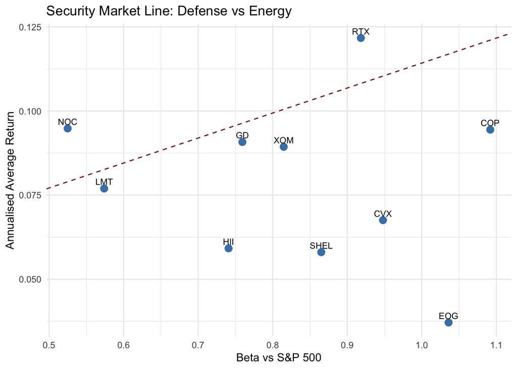

Interpretation: Plotting the assets against the Security Market Line shows that realized average returns do not line up perfectly with the CAPM benchmark. Some defense stocks sit slightly above the SML, reflecting mild positive pricing errors, while several energy names fall below, consistent with high volatility not fully compensated by higher realized returns. None of the deviations are dramatic, but as a group they suggest that market beta alone is not sufficient to explain the cross-sectional pattern of returns in this universe. This imbalance motivates the move toward additional factors.

### 5.3 Single-index vs full covariance: residual risk and diversification

```
##      Asset   TotalVar SystematicVar ResidualVar ResidualShare
## LMT    LMT 0.06282307    0.01285123  0.04997184     0.7954377
## NOC    NOC 0.07250038    0.01075118  0.06174920     0.8517087
## RTX    RTX 0.08943770    0.03290339  0.05653431     0.6321083
## GD      GD 0.05731051    0.02249865  0.03481186     0.6074254
## HII    HII 0.10244265    0.02141272  0.08102994     0.7909785
## XOM    XOM 0.09192857    0.02590483  0.06602374     0.7182070
## CVX    CVX 0.10049012    0.03506577  0.06542435     0.6510526
## SHEL  SHEL 0.10443496    0.02920622  0.07522874     0.7203406
## COP    COP 0.15906565    0.04652092  0.11254473     0.7075363
## EOG    EOG 0.18120428    0.04187832  0.13932596     0.7688889
```

Interpretation: Decomposing risk into systematic and residual components reveals that idiosyncratic volatility remains large for most assets. The market factor accounts for only a fraction of total variance; the rest comes from firm- or sector-specific shocks—such as defense contract news or abrupt movements in energy prices—that CAPM does not capture. Residual shares well above 50% confirm that diversification across these names is essential, and that the single-index model only partially approximates the true covariance structure. This also explains why R² values in the CAPM regressions were moderate rather than high.

### 5.4 Multifactor macro model: oil and term spread

```
## [1] "DCOILWTICO"
```

```
##    Asset         Alpha    Beta_MKT   Beta_Oil     Beta_Term    Alpha_p
## 1    LMT  0.0016253132  0.10444298 0.14496895 -2.217436e-03 0.33456531
## 2    NOC  0.0001433359 -0.00670462 0.08292077 -2.814566e-04 0.94128136
## 3    RTX -0.0002903264  0.92473465 0.11414812 -2.036976e-03 0.85069725
## 4     GD -0.0002889473  0.70261619 0.06480226 -3.688449e-04 0.83089600
## 5    HII -0.0030764596  1.00047698 0.19679767 -4.158934e-04 0.09838701
## 6    XOM -0.0003512581  0.82612092 0.28338825  4.975686e-03 0.88108008
## 7    CVX -0.0001309703  0.73818049 0.31765918  2.712688e-03 0.94166107
## 8   SHEL  0.0008584982  0.50006074 0.29193434 -4.830644e-05 0.69363974
## 9    COP  0.0012648771  0.81998048 0.34560555  3.185092e-03 0.60708958
## 10   EOG -0.0022967418  0.93100970 0.48301070  3.215632e-03 0.33704354
##           MKT_p        Oil_p     Term_p       AdjR2
## 1  4.859835e-01 2.715117e-02 0.21507543  0.05602023
## 2  9.691801e-01 2.681818e-01 0.89137694 -0.03001549
## 3  8.181111e-09 5.705660e-02 0.21544898  0.44455992
## 4  2.531178e-07 2.138884e-01 0.79689177  0.35785859
## 5  8.892308e-08 6.814499e-03 0.83094521  0.42309662
## 6  2.083702e-04 2.472034e-03 0.04918219  0.33938030
## 7  2.044552e-05 1.960732e-05 0.15603331  0.44170931
## 8  1.228754e-02 8.631579e-04 0.98329101  0.22246600
## 9  4.037134e-04 5.010039e-04 0.22394869  0.33074760
## 10 4.785436e-05 1.815238e-06 0.20575884  0.46287669
```

### 5.5 Portfolio optimisation with factor-adjusted expected returns

```
## $Weights
##    LMT    NOC    RTX     GD    HII    XOM    CVX   SHEL    COP    EOG
## 0.0299 0.0000 0.0000 0.0000 0.3845 0.0000 0.0013 0.2624 0.0000 0.3219
##
## $Return
## [1] 0.006003777
##
## $Risk
## [1] 0.2815547
##
## $Sharpe
## [1] -0.1207446
```

## 6 Market Efficiency Check

This section evaluates whether daily log returns for defense and energy stocks are consistent with market efficiency. First, I test the weak-form EMH by looking for autocorrelation using ACF plots, Ljung–Box tests, and Lo–MacKinlay variance-ratio statistics at short horizons (k = 2, 5, 10). Then I assess semistrong efficiency via an event study around the Russian invasion of Ukraine on 24 February 2022, measuring abnormal and cumulative abnormal returns for individual assets and for the GMV and tangency portfolios.

### 6.1 Weak-form EMH: Autocorrelation and Ljung–Box Tests

I start by computing autocorrelation functions up to lag 10 and running Ljung–Box portmanteau tests on daily log returns for all ten assets.

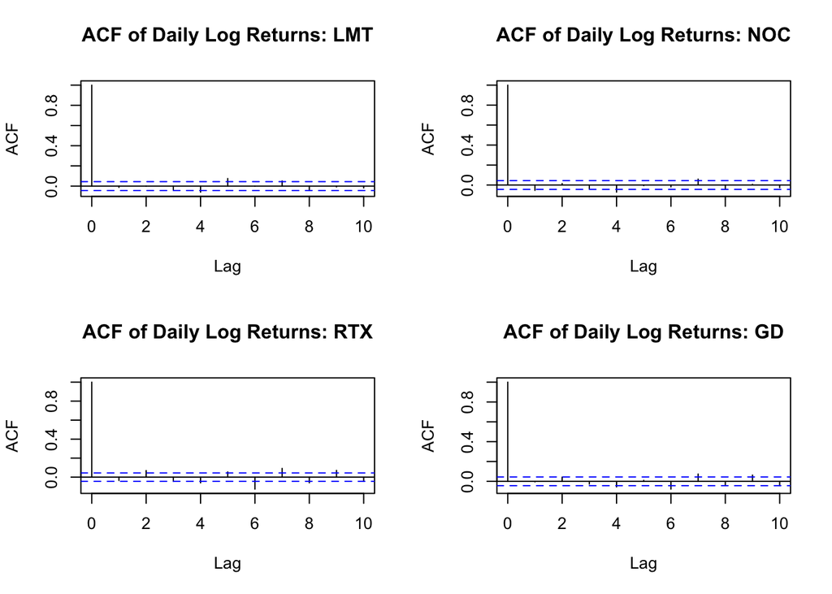

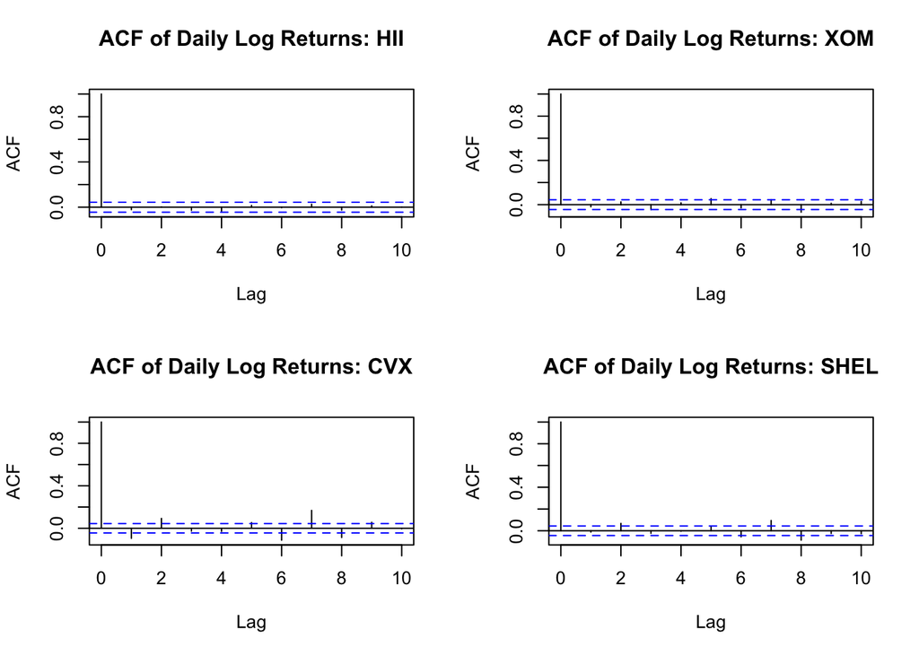

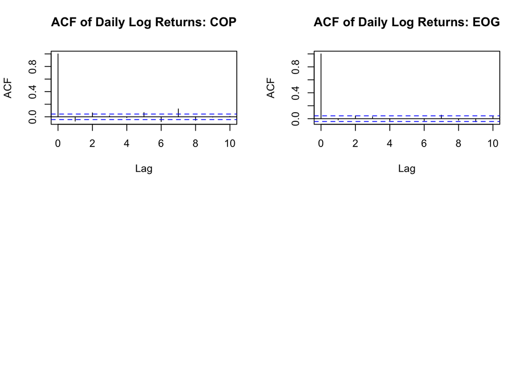

```
##    Asset Lag      P_value
## 1    LMT   1 0.5717552656
## 2    LMT   2 0.8522073705
## 3    LMT   3 0.4173950412
## 4    LMT   4 0.0406352273
## 5    LMT   5 0.0007583494
## 6    LMT   6 0.0017224328
## 7    LMT   7 0.0004434684
## 8    LMT   8 0.0002675858
## 9    LMT   9 0.0005225317
## 10   LMT  10 0.0007876441
## 11   NOC   1 0.0165848556
## 12   NOC   2 0.0464458973
## 13   NOC   3 0.0305241834
## 14   NOC   4 0.0007798919
## 15   NOC   5 0.0018486702
## 16   NOC   6 0.0030960571
## 17   NOC   7 0.0003820360
## 18   NOC   8 0.0001781684
## 19   NOC   9 0.0003582862
## 20   NOC  10 0.0004197312
```

Interpretation: Across the ten assets, Ljung–Box p-values reveal clear serial dependence once multiple lags are considered. Defense names like LMT, NOC, RTX, and GD produce extremely small p-values starting around lag 4, indicating that their return series are not perfectly white noise. Several energy stocks—CVX, SHEL, COP—show the same pattern. In contrast, HII stands out as the only series whose p-values remain comfortably large across all lags, making it the closest to an i.i.d. process. These results imply mild predictability at short horizons, though likely driven by microstructure effects rather than exploitable trading opportunities.

### 6.2 Weak-form EMH: Lo–MacKinlay Variance-Ratio Tests

To complement the autocorrelation evidence, I apply the Lo–MacKinlay variance-ratio test at horizons k = 2,5,10. Under a random walk, the variance of k-period returns should scale linearly with k, and the standardized test statistics (M1, M2) are asymptotically standard normal.

```
##    Asset  k          M1          M2
## 1    LMT  2 -0.57086182 -0.25603125
## 2    LMT  5 -1.52223141 -0.67086901
## 3    LMT 10 -0.79801835 -0.36184516
## 4    NOC  2 -2.39618568 -1.29972867
## 5    NOC  5 -2.59559119 -1.40279678
## 6    NOC 10 -2.81349048 -1.57902504
## 7    RTX  2 -1.56791867 -0.72137562
## 8    RTX  5 -0.68533138 -0.29814485
## 9    RTX 10 -1.19165105 -0.51639332
## 10    GD  2 -0.26372739 -0.14585244
## 11    GD  5 -0.09064237 -0.04778170
## 12    GD 10 -0.81896275 -0.43640417
## 13   HII  2 -0.95184518 -0.69688533
## 14   HII  5 -1.37561327 -0.98631583
```

[output cut: 16 more lines]

Interpretation: Most M1 and M2 statistics lie within the familiar ±1.96 bounds, meaning the random-walk hypothesis cannot be strongly rejected for many assets at horizons k = 2, 5, or 10. A few stocks show mild departures: NOC, COP, and RTX exhibit moderately negative statistics, consistent with slight mean reversion; CVX shows a very negative M1 value at k = 2 and a borderline-significant M2, also pointing toward short-horizon mean reversion. Overall, the deviations from the random-walk benchmark are modest and concentrated in only a subset of names, reinforcing the idea that daily returns are not perfectly i.i.d. but remain close to the random-walk benchmark.

### 6.3 Semistrong EMH: Event Study Around the Ukraine Invasion

To test semistrong-form efficiency, I analyze the reaction of markets to the Russian invasion of Ukraine on 24 February 2022, a major geopolitical shock that should affect both defense and energy stocks. Using CAPM betas estimated in the previous section, I compute abnormal returns and cumulative abnormal returns (CAR) over a symmetric event window of [−10,+10] trading days around the event. I also aggregate abnormal returns for the GMV and tangency portfolios constructed in Section 4.

```
##     LMT     NOC     RTX      GD     HII     XOM     CVX    SHEL     COP     EOG
##  0.1639  0.1747  0.0687  0.1532  0.1920  0.0640  0.1635 -0.0936  0.0921  0.0382
```

```
## [1] 0.1216361
```

```
## [1] 0.09750665
```

Interpretation: Cumulative abnormal returns around the Ukraine invasion are positive for nine of the ten assets, with the strongest reactions among defense contractors (HII, NOC, LMT, GD). Several energy names also show positive CARs (XOM, CVX, COP), while SHEL is the lone negative case. The GMV and tangency portfolios both produce positive CARs—roughly 0.12 and 0.10—signaling that diversified exposures to these sectors outperformed their CAPM-implied benchmarks around the event. The direction of the reaction is consistent with semistrong efficiency, but the fact that abnormal performance accumulates over many days rather than being instant suggests gradual adjustment to geopolitical news rather than fully immediate price incorporation.